# GPS tölfræði

Þorsteinn Aðalsteinsson

5 júní 2021

[output not shown]

```
## [1] NA
```

# Hvað er þetta?

Þessi úrvinnslubók skilar tölfræðilegum pælingum sem unnar eru úr gpx skjölum sem eru “target” á vinnubókinni

Í úrvinnslunni langar mig til að:

1. Búa til kort af leiðinni sem var farin
2. Búa til línurit af hraða sem var á leiðinni. Þetta línurit á að sýna LOWES smooth af hraðanum. Einnig langar mig til þess að búa til histogram af hraðadreifingunni
3. Búa til wind-rose af hraða vs stefnu, eða veglengd vs stefnu

## Gagnasöfnun

Gögnin í skjalinu eru í xml strúktur þar sem hver gagnapunktur er geymdur í “trkpt” entry. Hvert entry er með “lat” og “lon” gildum sem attribute. xmlValue eru síðan “ele” og “time”. Hér sæki ég gögnin með því að nota XML pakkan í R

- Fjöldi tímagilda: 570
- Upphafstími: 2022-10-18T15:58:38Z
- Lokatími: 2022-10-18T17:57:21Z

|  | lat | lon | ele | time |
| --- | --- | --- | --- | --- |
| 1 | 64.151104548946 | -21.9329083431512 | 14.17 | 2022-10-18T15:58:38Z |
| 2 | 64.1510559339076 | -21.9328957702965 | 14.14 | 2022-10-18T15:58:53Z |
| 3 | 64.1510115936399 | -21.9328434672207 | 14.19 | 2022-10-18T15:59:11Z |
| 4 | 64.1509763058275 | -21.9325815327466 | 14.1 | 2022-10-18T15:59:28Z |
| 5 | 64.1509834304452 | -21.9326190836728 | 13.97 | 2022-10-18T15:59:44Z |
| 6 | 64.1509783174843 | -21.9327158946544 | 14.04 | 2022-10-18T15:59:51Z |
| 7 | 64.1509799100459 | -21.9328461494297 | 13.68 | 2022-10-18T15:59:59Z |
| 8 | 64.1509508248419 | -21.9331160467118 | 13.92 | 2022-10-18T16:00:12Z |
| 9 | 64.1509399283677 | -21.9332093372941 | 13.47 | 2022-10-18T16:00:16Z |
| 10 | 64.1508950013667 | -21.9339285045862 | 13.47 | 2022-10-18T16:00:45Z |

[output cut: 560 more lines]

## Útreikningar

Út frá gögnunum reikna ég:

1. Vegalengd á milli hnita. Hér nota ég raster::pointDistance fallið. Einhverra hluta vegna virðist vegalengdin tvöfaldast við þessa reikninga.
2. Stefnu á milli hnita. Hér nota ég Haversine jöfnuna. Stefnan er sett frá 0-360 gráðu skala
3. Tímabil á milli punkta. Hér finnst mér sem að tíminn sé ósennilega alltaf heilar sekúndur, en það er fátt sem ég get gert til þess að finna nákvæmari tölur í gögnunum
4. Hraða (í m/s og km/klst) á milli punkta (þetta er nokkuð “noisy” upplýsingar)+
5. LOWESS mýkt fall fyrir hraða (km/klst) með pillu-stærðina 0,01
6. LOWESS mýkt fall fyrir hæð (ele)
7. LOWESS mýkt fall fyrir bearing
- Samtals vegalengd: 1.5556459842^{4} metrar
- Samtals logg-tími: 1.9786111111 klukkustundir

# Grunn teikningar:

## Hraði (km/klst)

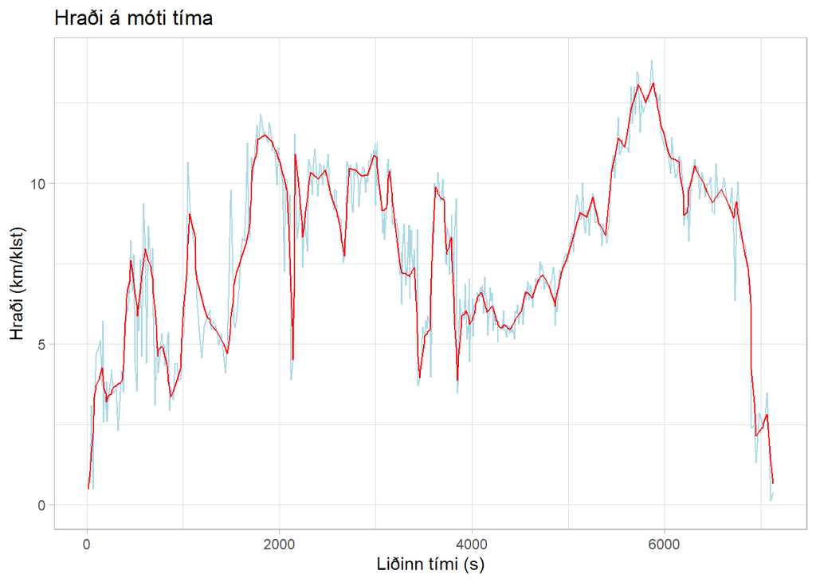

Önnur sýn á gögnin er histogram af hraðanum.

[figure not shown]

Hraði og stefna. Við gerum ráð fyrir að hraðinn fari nokkuð eftir því í hvaða stefnu er verið að sigla, þar sem beiting og lens vindur er yfirleitt hægari en reach og hliðarvindur. Hér er vindstefnan ekki skráð sérstaklega þannig að notast er við mælda gps stefnu.

Hér hnika ég gögnunum aðeins til og reikna meðalhraða fyrir siglingastefnu sem skipt er niður í 30 jafna gráðubúta. Til viðbótar hafna ég út punktum þar sem hraðinn er undir 3 km/klst. Þetta gildi gæti þýtt að mikið af gögnum fellur út á rólegum dögum, þar sem þetta er rólegur gönguhraði.

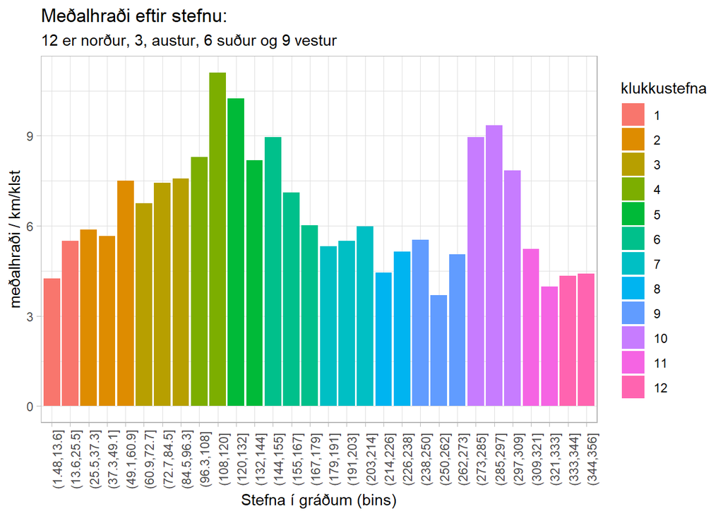

Heildar vegalengt eftir stefnu. Þegav við siglum beitivind þarf að fara lengri vegalengd en þegar er siglt beint undan vindi. Við komumst heldur nánast enga vegalengd beint upp í vindinn. Með því að skoða samtals siglda vegalengd er þannig hægt að finna nokkuð nákvæmlega hvaða stefna jafngildir “móti vindi”. Þetta getur hins vegar verið skekkt af ef siglingasvæðið er aðþrengt.

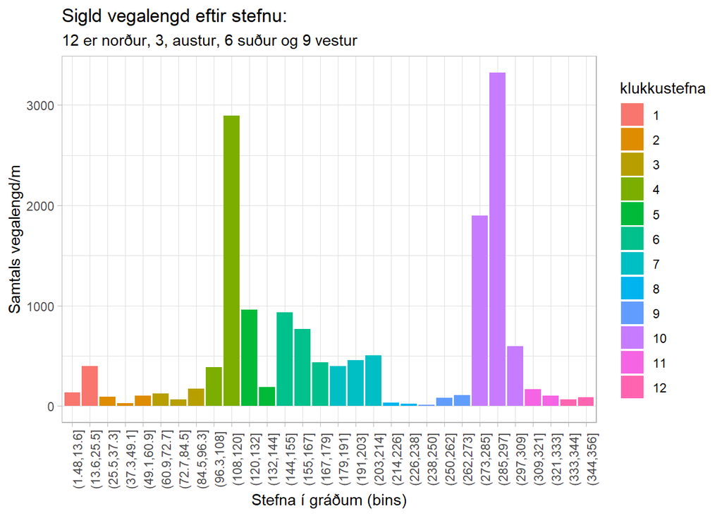

## Siglingin á korti

Hér þarf ég að sækja “bounding box” fyrir kortagögn frá Google. Ég sæki þetta box þannig að allir punktarinr passi inn í rammann. Þetta getur hins vegar þýtt að það þarf að sækja mjög mikkið af gögnum, eða þá að lítið sjáist í land á myndunum.

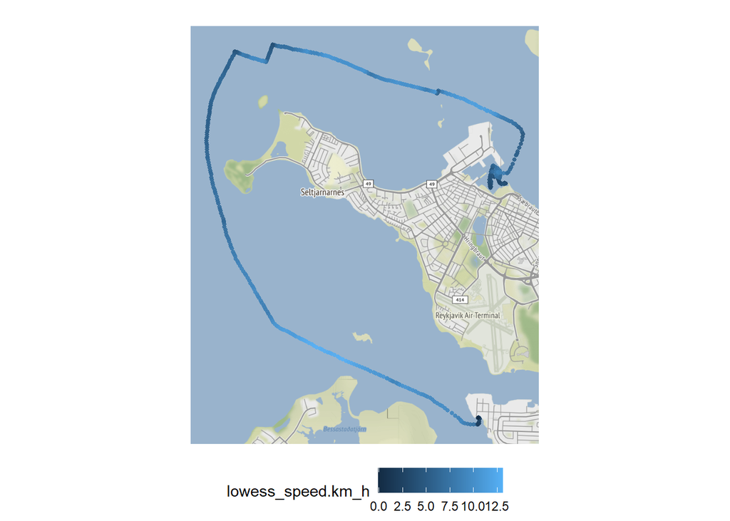